# load_data_and_QC

## Load data and QC

After aligning scATAC-seq reads to a reference genome, its important to evaluate data quality. `Socrates2` allows facile loading and analysis of scATAC-seq data, requiring only a BED file with the Tn5 integration sites (analagous to the ends of the fragments.tsv file from 10X) with 5 columns (chr start end barcode strand), a GFF file with gene coordinates, and a chromosome sizes file with one chromosome per line (chr chr_length). The output is `obj` with several slots (1) `obj$bed` which contains the single-bp Tn5 integration sites for each barcode; (2) `obj$gff` genome GFF annotation as TxDb object; (3) `obj$chr` a data.frame with the chromosome sizes of the genome. If MACS2 is not in your path, you will receive an error and will be booted from the session. Make sure MACS2 is available! We will use some freely available data from 10X Genomics that is provided with this package. The Tn5 integration site bed file has been subset to 2 million Tn5 sites for quick processing and to circumvent limitations on file size uploads on GitHub.

**Inputs** (Required):  
1. **-script_dir** (a script directory downloaded from GitHub: Socrates2/utils/input_other_required_scripts_dir)  
2. **-tn5_fl opt_tn5_mq10.bed** (A file obtained from [Processing bam](http://htmlpreview.github.io/?https://github.com/yanhaidong1/Socrates2/blob/main/vignettes/process_BAM.html)  
3. **-Ggff_fl gene.gff3**  
4. **-chrsize_fl chr_size.txt**  
5. **-o output_dir** (mkdir output_dir)  
6. **-Pt_chr_name** (Chloroplast chromosome name in the gff file)  
7. **-Mt_chr_name** (Mitochondria chromosome name in the gff file)

**Overall parameters** (Optional):  
**parameters:** when initiating **-open_build_obj**:  
1. **-open_build_obj yes|no** (Build and store all the data into an object. Default: yes)  
2. **-shift -75** (Shift the start coordinates upstream when calling macs2 tool. Default: 75)  
3. **-extsize 150** (Extends the fragment length downstream when calling macs2 tool. Default: 150)  
4. **-fdr 0.1** (Significance cut-off for peak calling when calling macs2 tool. Default: 0.1)  
5. **-tss_size 2000** (Size of windows flanking TSS for estimating proportion of Tn5 integration sites near gene TSSs. Default: 2000)

**parameters:** when initiating **-open_find_cells**:  
1. **-open_find_cells yes|no** (Filter QC and build an overall data quality. Default: yes)  
2. **-ipt_raw_obj prefix.raw_obj.qs2** (Provide an object file obtained from the -open_build_obj.)  
3. **-min_cells 1000** (Lower limit on the number of identified cells. Default: 1000)  
4. **-max_cells 16000** (Upper limit on the number of identified cells. Default: 16000)  
5. **-min_tn5 1000** (Lower threshold for the minimum number of Tn5 integration sites for retaining obj barcode. Default: 1000)  
6. **-org_flt_thresh 0.2** (Remove cells with an organelle ratio (Organalle/Total_reads) greater than N. Default: 0.2)  
7. **-tss_min_freq 0.2** (Minimum frequency of Tn5 sites near TSSs. Default: 0.2)  
8. **-tss_z_thresh 2** (Z-score threshold to remove barcodes below the mean. Default: 2)  
9. **-frip_min_freq 0.2** (Minimum frequency of Tn5 sites within ACRs. Default: 0.2)  
10. **-frip_z_thresh 2** (Z-score threshold to remove barcodes with values below X standard deviations from the mean. Default: 2)  
11. **-knee_plot_filter yes|no** (Use the knee plot with slope-based filtering to exclude cells that do not meet the required criteria.)

**Parameters:** when initiating **-open_is_cells**:  
1. **-open_is_cells yes|no** (Compares each barcode to background and cell bulk reference to identify barcodes representing ambient DNA or broken nuclei. Default: yes)  
2. **-ipt_findcell_obj prefix.findcell_obj.qs2** (Provide an object obtained from the -open_find_cells.)  
3. **-num_test 20000**(Number of barcodes to query (ranked by total # of unique Tn5 insertions. Default: 20000)  
4. **-num_tn5 NULL** (Set the minimum number of Tn5 insertions to select test cells. Overridden by num.test. Default: NULL)  
5. **-num_REF 1000** (Number of cells to use as the cell bulk reference (top X cells based on # unique Tn5 insertions). Default: 1000)  
6. **-background_cutoff 100** (Maximum unique Tn5 insertions to use for selecting barcodes for the background reference set. Default: 100)

**Other parameters**  
1. **-prefix** (Provide a prefix added in the output files. Default: output)  
2. **-win_size 500** (Divide the genome into multiple bins/windows, and each bin/window spans a specific size (bp). Default: 500)

**parameters:** when initiating **-open_replicate_check**:  
1. **-open_replicate_check yes|no** (Enable or disable replication checking between two replicate samples. Default: no)  
2. **-rep_check_method IDR** (Specify the method used for replication checking. (Default: IDR)  
3. **-rep1_obj prefix.findcell_obj.qs2** (Specify the object file obtained from the -open_find_cells step for one of the replicates. The file should follow the naming convention prefix.findcell_obj.qs2.)  
4. **-rep2_obj prefix.findcell_obj.qs2** (Specify the object file obtained from the -open_find_cells step for the other replicate. The file should follow the naming convention prefix.findcell_obj.qs2.)

**Outputs**  
1. **prefix.QC.qs2**  
2. **prefix.QC_FIGURES.pdf**  
3. **prefix.filtered.soc.qs2**  
4. **prefix.metadata.txt**  
5. **prefix.raw_obj.qs2**  
6. **prefix.findcell_obj.qs2**

### Step01: Process data

### Option 1: Run all the steps at once

A particularly useful metric of data quality can be estimated by counting the proportion of Tn5 integration sites that are localized to significantly enriched regions of the genome. To estimate the fraction of reads in peaks (FRiP), `Socrates2` can run MACS2 on the bulk Tn5 integration sites and count the number of integration sites per barcode.

The metadata slot contains essential information for filtering out low-quality barcodes. Cells are filtered by setting thresholds such as a minimum total read depth of **-min_tn5 1000** (requiring at least 1000 Tn5 integration sites per cell), a maximum number of cells with **-max_cells 16000**, a minimum proportion of reads mapping to TSSs with **-tss_min_freq 0.2** and **-tss_z_thresh 2** (default values of 0.2 and a z-score of 2), and FRiP scores for barcodes with **-frip_min_freq 0.2** and **-frip_z_thresh 2** (also with defaults of 0.2 and a z-score of 2).

This pipeline offers enhanced cell filtration to identify cell barcodes that may represent ambient DNA or broken nuclei by comparing each barcode to background and cell bulk references. Parameters can be adjusted to refine the filtration, including **-num_test** (number of barcodes to query, ranked by the total number of unique Tn5 insertions. Default: 20000), **-num_REF**(number of cells to use as the cell bulk reference, selecting the top cells based on unique Tn5 insertions. Default: 1000), and **-background_cutoff** (maximum unique Tn5 insertions for selecting barcodes for the background reference set. Default: 100).

**Running**:  
**Note**: Because this step processes each library individually, it is advisable to use the `-prefix` option to assign a short, descriptive name instead of the default **output**. For example, you can represent a library as leaf1 by specifying `-prefix` **leaf1**.

```bash
python Socrates2/utils/load_and_QC_data.py
-script_dir Socrates2/utils/input_other_required_scripts_dir
-o output_dir
-tn5_fl opt_tn5_mq10.bed
-Ggff_fl gene.gff3
-chrsize_fl chr_size.txt
-Pt_chr_name ChrPt
-Mt_chr_name ChrMt
-prefix leaf1
```

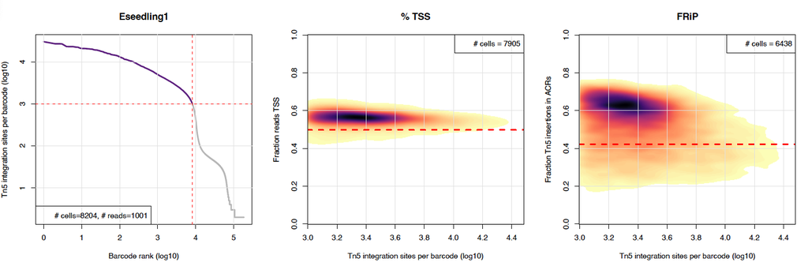

Figure 1: example of QC output

### Option 2: Start from “prefix.raw_obj.qs2”

If users wish to adjust parameters during the filtration step, they can set **-open_build_obj no** to save time. Additionally, users can modify the parameters listed above to filter cell barcodes. **Running**:

```bash
python Socrates2/utils/load_and_QC_data.py
-script_dir Socrates2/utils/input_other_required_scripts_dir
-o output_dir
-open_build_obj no
-open_find_cells yes
-open_is_cells yes
```

### Option 3: Start from “prefix.findcell_obj.qs2”

If users wish to adjust parameters in the final filtration step, which compares to the background for filtration, they can set **-open_build_obj no** and **-open_find_cells no** to save time. Additionally, users can modify the parameters listed above to filter cell barcodes.

**Running**:

```bash
python Socrates2/utils/load_and_QC_data.py
-script_dir Socrates2/utils/input_other_required_scripts_dir
-o output_dir
-open_build_obj no
-open_find_cells no
-open_is_cells yes
```

### Step02: Check replicate consistency

Here, we will perform replicate consistency analysis using the IDR (Irreproducible Discovery Rate) method. The IDR method is described in detail: https://github.com/nboley/idr. The input data consist of two object files generated from the -open_find_cells step, typically named prefix.findcell_obj.qs2 for each replicate.

The output includes an **idr_summary.log** file, which records the total number of reported peaks, the number of peaks passing the IDR cutoff of 0.05, and the corresponding percentage.

**Running**:

```bash
python Socrates2/utils/load_and_QC_data.py
-script_dir Socrates2/utils/input_other_required_scripts_dir
-o output_dir
-open_replicate_check yes
-rep1_obj /Path/to/rep1/prefix.findcell_obj.qs2
-rep2_obj /Path/to/rep2/prefix.findcell_obj.qs2
```

**Outputs**  
1. **output_dir/Replication_consistency_check_dir/idr_summary.log**  
2. **output_dir/Replication_consistency_check_dir/opt_output_idr.txt.png**